# Job-Shop Scheduling (Flexible)

(Calum McConville, Australia, 2022)

- Build model in or-tools (constraint programming) using SAT solver
- Model allows to specify resource constraints, time constraints for tasks, task sequence
- or-tool Job Shop scheduling: https://developers.google.com/optimization/scheduling/job_shop
- Wiki Job Shop scheduling: https://en.wikipedia.org/wiki/Job_shop_scheduling

### Job-Shop definition:

Multiple jobs are processed on several machines. Each job consists of a sequence of tasks (with varying durations), which must be performed in a given order, and each task must be processed on a specific machine (or on a set of alternative machines). For example, the job could be the manufacture of a single consumer item, such as an automobile. The problem is to schedule the tasks on the machines so as to minimize the length of the schedule—the time it takes for all the jobs to be completed.

### Model allows to define:

- Indidual duration for each Task-Machine combination (if no duration specified task can't be performed on machine)
- Sequence of task (sequence depedency contraints)
- Time windows for start and end of tasks (e.g. Task 1 should start no later than 1pm and finish no later than 4pm)

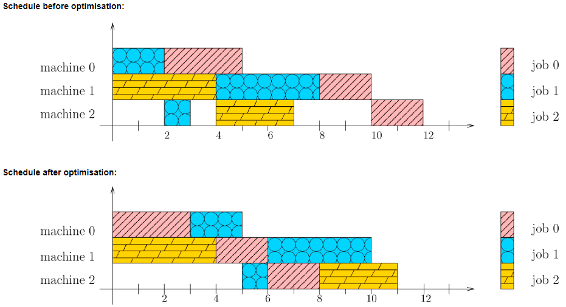

## Load libraries

- to install or-tools visit https://developers.google.com/optimization/
- or-tools model examples:
  - Hakank page - http://www.hakank.org/google_or_tools/
  - Github page - https://github.com/google/or-tools/tree/stable/examples/python

```python
from __future__ import print_function
from ortools.sat.python import cp_model
```

```python
import pandas as pd
import numpy as np
```

## Load data

### Load data from excel file

- Define path to excel file with inputs
- Each tab of excel file contain different part of the model inputs:
  - Job definition
  - Task definition and Job it belongs to
  - Machine definition
  - Durations for task on different machines (if entry is absent for particular task-machine pair it means task can't be performed on this machine)
  - Resources limits
  - Resources requirements for each task
  - Task sequence dependencies
  - Task start time windows
  - Task end time windows

```python
folder = './Data/'
filename = 'Input_data_small.xlsx'

file = folder+filename
print(file)
```

```
./Data/Input_data_small.xlsx
```

#### Input - "Jobs" list

- List of Jobs that have to be scheduled

```python
#Jobs
jobs_df = pd.read_excel(file,sheet_name='Jobs')
jobs_df = jobs_df.dropna(axis=1, how='all')
jobs_df.head(10)
```

|  | JobName | JobIndex | JobDescription |
| --- | --- | --- | --- |
| 0 | Job1 | 1 | Dummy Job1 |
| 1 | Job2 | 2 | Dummy Job2 |

#### Input - "Tasks" list

- For each task define Job it belongs to
- If the no Jobs, you can define individual job for each Task (Job=Task)

```python
job_task_df = pd.read_excel(file,sheet_name='JobTask')
job_task_df = job_task_df.dropna(axis=1, how='all')
job_task_df.head(10)
```

|  | JobName | TaskName | TaskIndex | TaskDescription |
| --- | --- | --- | --- | --- |
| 0 | Job1 | Task1 | 1 | Dummy Task 1 |
| 1 | Job1 | Task2 | 2 | Dummy Task 2 |
| 2 | Job1 | Task3 | 3 | Dummy Task 3 |
| 3 | Job1 | Task4 | 4 | Dummy Task 4 |
| 4 | Job1 | Task5 | 5 | Dummy Task 5 |
| 5 | Job1 | Task6 | 6 | Dummy Task 6 |
| 6 | Job1 | Task7 | 7 | Dummy Task 7 |
| 7 | Job1 | Task8 | 8 | Dummy Task 8 |
| 8 | Job1 | Task9 | 9 | Dummy Task 9 |
| 9 | Job1 | Task10 | 10 | Dummy Task 10 |

#### Input - "Machines"

- List of Machines
- Machine Index should be unique - it is used to map machines to task during optimisation

```python
machines_df = pd.read_excel(file,sheet_name='Machines')
machines_df = machines_df.dropna(axis = 1, how='all')
machines_df.head(10)
```

|  | MachineName | MachineIndex | MachineDescription |
| --- | --- | --- | --- |
| 0 | M1 | 1 | Dummy Machine 1 |
| 1 | M2 | 2 | Dummy Machine 2 |
| 2 | M3 | 3 | Dummy Machine 3 |

#### Input - "Task-Machine duration"

- Durations for each feasible Task-Machine pair
- If Task-Machine pair is not specified, it means that the task can't be done on that machine

```python
task_to_machine_df = pd.read_excel(file,sheet_name='TaskMachineDuration')
task_to_machine_df = task_to_machine_df.dropna(axis = 1, how='all')
task_to_machine_df.head(10)
```

|  | MachineName | MachineIndex | TaskName | Duration |
| --- | --- | --- | --- | --- |
| 0 | M1 | 1 | Task1 | 6 |
| 1 | M1 | 1 | Task2 | 2 |
| 2 | M1 | 1 | Task3 | 9 |
| 3 | M1 | 1 | Task4 | 5 |
| 4 | M1 | 1 | Task5 | 8 |
| 5 | M1 | 1 | Task6 | 1 |
| 6 | M1 | 1 | Task7 | 8 |
| 7 | M1 | 1 | Task8 | 7 |
| 8 | M1 | 1 | Task9 | 6 |
| 9 | M1 | 1 | Task10 | 8 |

#### Input - "Resource limits"

- Define total limist for resources that can be used at the same time
- *Example:* resource can be commodity skill worker or particular space that has limited capacity

```python
resources_df = pd.read_excel(file,sheet_name='ResourcesLimits')
resources_df = resources_df.dropna(axis = 1, how='all')
resources_df.head(10)
```

|  | ResourceName | Limit | ResourceDescription |
| --- | --- | --- | --- |
| 0 | R1 | 2 | Dummy Resource 1 |
| 1 | R2 | 2 | Dummy Resource 2 |

#### Input - "Resource requirements"

- Define resource requirements for each task
- Each row is a Task-Resource pair
- If Task requires two different type of resource you need to specify two rows - one for each resource
- *Example:* resource can be commodity skill worker or particular space that has limited capacity

```python
task_resources_df = pd.read_excel(file,sheet_name='TaskResources')
task_resources_df = task_resources_df.dropna(axis = 1, how='all')
task_resources_df.head(10)
```

|  | TaskName | ResourceName | Qty |
| --- | --- | --- | --- |
| 0 | Task1 | R1 | 1 |
| 1 | Task2 | R2 | 1 |
| 2 | Task3 | R1 | 1 |
| 3 | Task4 | R1 | 1 |
| 4 | Task5 | R2 | 2 |
| 5 | Task6 | R2 | 2 |
| 6 | Task7 | R2 | 2 |
| 7 | Task8 | R2 | 2 |
| 8 | Task9 | R2 | 1 |
| 9 | Task10 | R1 | 2 |

#### Input - "Task sequence requirement"

- Define all task sequence dependencies here
- One row is a single dependency
- If task is dependent on two other task you need to specify two rows - one for each dependency
- *Example:* Task requires "assembly" must be scheduled only after "painting" task has been completed

```python
task_precedence_df = pd.read_excel(file,sheet_name='TaskPrecedence')
task_precedence_df = task_precedence_df.dropna(axis = 1, how='all')
task_precedence_df.head(10)
```

|  | TaskName | PrecedingTaskName | isImmediateStart |
| --- | --- | --- | --- |
| 0 | Task2 | Task1 | 1.0 |
| 1 | Task4 | Task3 | NaN |
| 2 | Task4 | Task1 | NaN |

#### Input - "Task Start window"

- Define task that have to **start** within particular time window
- *Example:* Maintenance task has to be schedule during lunch break

```python
task_start_window_df = pd.read_excel(file,sheet_name='TaskStartWindow')
task_start_window_df.head(10)
```

|  | TaskName | StartAfter | StartBefore |
| --- | --- | --- | --- |
| 0 | Task1 | 1 | 9 |

#### Input - "Task End window"

- Define task that have to **end** within particular time window
- *Example:* Task must be completed in first half of the day

```python
task_end_window_df = pd.read_excel(file,sheet_name='TaskEndWindow')
task_end_window_df.head(10)
```

|  | TaskName | EndAfter | EndBefore |
| --- | --- | --- | --- |
| 0 | Task2 | 1 | 9 |

## Model

#### Reference doc: https://github.com/google/or-tools/blob/master/ortools/sat/doc/reference.md

##### Create model object

- cp_model - constraint programming model or **CP** (another name is constrain satisfaction model or **SAT**)

```python
model = cp_model.CpModel()
```

##### Define max time horizon for scheduling

- Horison is maximum period of time for schedule
- If resulting schedule can't fit into horizon it will return infeasible solution
- It is better to specify horizon with some extra space to get at least feasible solution and then tighet the horizon if required
- Sometimes the horizon is a representation of a day, and number represents number of time slots in a day
  - *Example*: if we model with 30 minutes granularity than day is represented as 24*2 = 48 timeslots horizon
  - *Example*: if we model with 5 minutes granularity than day is represented as 24*12 = 288 timeslots horizon

```python
## Calculate horizon as sum of all task durations multiplied by 2
horizon = int(task_to_machine_df.groupby('TaskName').Duration.max().sum()*2)
print ('Max horizon is:', horizon)

## Overwrite horizon with large enough number
#horizon = 100
```

```
Max horizon is: 424
```

##### Create enumerated list of machines

- This list is used later to define domain of decision variable

```python
machine_list = machines_df.MachineIndex.unique().tolist()
machine_list_0 = [0]+machine_list
machine_n = len(machine_list)
print ("Total machines :",machine_n)
print ("Machines list  :",machine_list)
print ("Including 0    :",machine_list_0)
```

```
Total machines : 3
Machines list  : [1, 2, 3]
Including 0    : [0, 1, 2, 3]
```

## Decision variables

All decision variables are stored within pandas dataframes, it allows to simplify and streamline the modelling

### Task-To-Machine variables

- Local variables - means they are optional and can be 0 (not defined)
- When task is finaly assigned to a machine the master decision variable for task get copies of the locally defined values

##### Var - isAssigned

- **Main decision variable**, Indicator that particular task is assigned to particular machine
- Boolean type

```python
task_to_machine_df['isAssigned'] = task_to_machine_df.apply(lambda row:
                                         model.NewBoolVar(row.TaskName + '->' + row.MachineName + ' assigned')
                                        ,axis=1)
```

##### Var - LocalTaskStart

- **Main decision variable**, Start time for the task
- Integer type
- 0 if not assigned, >=1 if assigned (this enforced later with constraint)

```python
task_to_machine_df['LocalTaskStart'] = task_to_machine_df.apply(lambda row:
                                         model.NewIntVar(0,horizon, row.TaskName + '->' + row.MachineName + ' start')
                                        ,axis=1)
```

##### Var - LocalTaskDuration

- Duration of the task (will be flexible in next version)
- Integer type
- 0 if not assigned, >=1 if assigned (this enforced later with constraint)

```python
task_to_machine_df['LocalTaskDuration'] = task_to_machine_df.apply(lambda row:
                                         model.NewIntVar(0,horizon, row.TaskName + '->' + row.MachineName + ' duration')
                                        ,axis=1)
```

##### Var - LocalTaskEnd

- End time for the task
- Integer type
- 0 if not assigned, >=1 if assigned (this enforced later with constraint)

```python
task_to_machine_df['LocalTaskEnd'] = task_to_machine_df.apply(lambda row:
                                         model.NewIntVar(0,horizon, row.TaskName + '->' + row.MachineName + ' end')
                                        ,axis=1)
```

##### Var - LocalTaskInterval

- Special or-tools variable that defines interval for a task
- This variable also binds together Start Duration and End variables in a rule Start + Duration = End
- Optional Interval type (special)
- 0 if not assigned, >=1 if assigned

```python
task_to_machine_df['LocalTaskInterval'] = task_to_machine_df.apply(lambda row:
                                            model.NewOptionalIntervalVar(
                                            row.LocalTaskStart,
                                            row.LocalTaskDuration,
                                            row.LocalTaskEnd,
                                            row.isAssigned,
                                            row.TaskName + '->' + row.MachineName + ' interval')
                                        ,axis=1)
```

##### Var - LocalMachineAssigned

- Variable that indicates what machine is performing task
- This variable is used in master Task table
- 0 if not assigned, >=1 if assigned

```python
task_to_machine_df['LocalMachineAssigned'] = task_to_machine_df.apply(lambda row:
                                          model.NewIntVar(0, machine_n, row.TaskName + ' machine')
                                        ,axis=1)
```

Show current content of dataframe with decision variables stored in the pandas series:

```python
task_to_machine_df.head(2)
```

|  | MachineName | MachineIndex | TaskName | Duration | isAssigned | LocalTaskStart | LocalTaskDuration | LocalTaskEnd | LocalTaskInterval | LocalMachineAssigned |
| --- | --- | --- | --- | --- | --- | --- | --- | --- | --- | --- |
| 0 | M1 | 1 | Task1 | 6 | Task1->M1 assigned | Task1->M1 start | Task1->M1 duration | Task1->M1 end | Task1->M1 interval | Task1 machine |
| 1 | M1 | 1 | Task2 | 2 | Task2->M1 assigned | Task2->M1 start | Task2->M1 duration | Task2->M1 end | Task2->M1 interval | Task2 machine |

### Task Master variables

- Master variables - this variables are populated from Local Task variables with final values (picked alternative)
- When task is finaly assigned to a machine the master decision variable for task get copies of the locally defined values

##### Var - TaskStart

- Master variable indicates start time of the task
- This variable is populated (via constraint) from local variable
- Integer type

```python
job_task_df['TaskStart'] = job_task_df.apply(lambda row:
                                         model.NewIntVar(0,horizon, row.TaskName + ' start')
                                        ,axis=1)
```

##### Var - TaskDuration

- Master variable indicates duration of the task
- This variable is populated (via constraint) from local variable
- Integer type

```python
job_task_df['TaskDuration'] = job_task_df.apply(lambda row:
                                         model.NewIntVar(0,horizon, row.TaskName + ' duration')
                                        ,axis=1)
```

##### Var - TaskEnd

- Master variable indicates end time of the task
- This variable is populated (via constraint) from local variable
- Integer type

```python
job_task_df['TaskEnd'] = job_task_df.apply(lambda row:
                                         model.NewIntVar(0,horizon, row.TaskName + ' end')
                                        ,axis=1)
```

##### Var - TaskInterval

- Special or-tools variable that defines interval for a task
- This variable also binds together Start Duration and End variables in a rule Start + Duration = End
- Interval type (special)

```python
job_task_df['TaskInterval'] = job_task_df.apply(lambda row:
                                        model.NewIntervalVar(
                                            row.TaskStart,
                                            row.TaskDuration,
                                            row.TaskEnd,
                                            row.TaskName + ' interval')
                                        ,axis=1)
```

##### Var - MachineAssigned

- Master variable that indicates what machine is performing task
- This variable is populated (via constraint) from local variable
- Integer type

```python
job_task_df['TaskMachine'] = job_task_df.apply(lambda row:
                                         #model.NewEnumeratedIntVar(machine_list, row.TaskName + ' machine')
                                         model.NewIntVar(1, machine_n, row.TaskName + ' machine')
                                        ,axis=1)
```

Show current content of dataframe with decision variables stored in the pandas series:

```python
job_task_df.head(2)
```

|  | JobName | TaskName | TaskIndex | TaskDescription | TaskStart | TaskDuration | TaskEnd | TaskInterval | TaskMachine |
| --- | --- | --- | --- | --- | --- | --- | --- | --- | --- |
| 0 | Job1 | Task1 | 1 | Dummy Task 1 | Task1 start | Task1 duration | Task1 end | Task1 interval | Task1 machine |
| 1 | Job1 | Task2 | 2 | Dummy Task 2 | Task2 start | Task2 duration | Task2 end | Task2 interval | Task2 machine |

### Job variables

- This variables are populated from Master Task variables
- They define start time of the first task in the job and end time of the last task

##### Var - JobStart

- Master variable indicates start time of the job
- This variable is populated (via constraint) from master task variable
- Integer type

```python
jobs_df['JobStart'] = jobs_df.apply(lambda row:
                                         model.NewIntVar(0,horizon, row.JobName + ' start')
                                        ,axis=1)
```

##### Var - JobEnd

- Master variable indicates end time of the job
- This variable is populated (via constraint) from master task variable
- Integer type

```python
jobs_df['JobEnd'] = jobs_df.apply(lambda row:
                                         model.NewIntVar(0,horizon, row.JobName + ' end')
                                        ,axis=1)
```

##### Var - JobDuration

- Master variable indicates total duration of the job (including iddle time in between the tasks)
- This variable is populated (via constraint) from master task variable
- Integer type

```python
jobs_df['JobDuration'] = jobs_df.apply(lambda row:
                                         model.NewIntVar(0,horizon, row.JobName + ' duration')
                                        ,axis=1)
```

##### Var - JobInterval

- Special or-tools variable that defines interval for a job
- This variable also binds together Start Duration and End variables in a rule Start + Duration = End
- Interval type (special)

```python
jobs_df['JobInterval'] = jobs_df.apply(lambda row:
                                        model.NewIntervalVar(
                                            row.JobStart,
                                            row.JobDuration,
                                            row.JobEnd,
                                            row.JobName + ' interval')
                                        ,axis=1)
```

Show current content of dataframe with decision variables stored in the pandas series:

```python
jobs_df.head(2)
```

|  | JobName | JobIndex | JobDescription | JobStart | JobEnd | JobDuration | JobInterval |
| --- | --- | --- | --- | --- | --- | --- | --- |
| 0 | Job1 | 1 | Dummy Job1 | Job1 start | Job1 end | Job1 duration | Job1 interval |
| 1 | Job2 | 2 | Dummy Job2 | Job2 start | Job2 end | Job2 duration | Job2 interval |

## Constraints

### Conditional constraintrs for Local Task variables - .OnlyEnforceIf()

- For local variables only one set of variables can be activated ("isAssigned"), i.e. only one machine can be assigned to task and vica versa
- When set of variables is not activated we set all the decision variables to 0
- When set of variables is activated we ensure that non of the decision variables has 0 values
- Method .Add() is a constraint adding method, OnlyEnforceIf() enforces constaint only when "isAssigned" is True

#### if "Not assigned" then "Start = 0"

```python
#Define start= 0 if not selected
task_to_machine_df['xStart0'] = task_to_machine_df.apply(lambda row:
                                         model.Add(row.LocalTaskStart == 0)
                                        .OnlyEnforceIf(row.isAssigned.Not())
                                        ,axis=1)
```

#### if "assigned" then "Start > 0"

```python
#Define start= 0 if not selected
task_to_machine_df['xStartNon0'] = task_to_machine_df.apply(lambda row:
                                         model.Add(row.LocalTaskStart > 0)
                                        .OnlyEnforceIf(row.isAssigned)
                                        ,axis=1)
```

#### if "Not assigned" then "Duration = 0"

```python
#Define duration= 0 if not selected
task_to_machine_df['xDuration0'] = task_to_machine_df.apply(lambda row:
                                         model.Add(row.LocalTaskDuration == 0)
                                        .OnlyEnforceIf(row.isAssigned.Not())
                                        ,axis=1)
```

#### if "assigned" then "Duration > 0"

```python
#Define duration= required_duration if selected
task_to_machine_df['xDurationNon0'] = task_to_machine_df.apply(lambda row:
                                         model.Add(row.LocalTaskDuration == row.Duration)
                                        .OnlyEnforceIf(row.isAssigned)
                                        ,axis=1)
```

#### if "Not assigned" then "Machine = 0"

```python
task_to_machine_df['xMachine0'] = task_to_machine_df.apply(lambda row:
                                         model.Add(row.LocalMachineAssigned == 0)
                                        .OnlyEnforceIf(row.isAssigned.Not())
                                        ,axis=1)
```

#### if "assigned" then "Machine > 0"

```python
task_to_machine_df['xMachineNon0'] = task_to_machine_df.apply(lambda row:
                                         model.Add(row.LocalMachineAssigned == row.MachineIndex)
                                        .OnlyEnforceIf(row.isAssigned)
                                        ,axis=1)
```

### Link Constraints

#### Link Local and Master Task decision variables

- Copy master variable into local variable table and apply equality constraint enforcment:

  ```
    * OnlyEnforceIf()
  ```

- We don't need to link duration as it is binded with start and end variables via Interval variable

##### Link Start times

- Copy TaskStart variable from Master table to Local table
- When task-machine assigned - enforce the equality link between Local and Master variables

```python
#copy variable
task_to_machine_df = task_to_machine_df.merge(job_task_df[['TaskName','TaskStart']], left_on='TaskName',right_on='TaskName')

#enforce links when assigned
task_to_machine_df['xStartLink1'] = task_to_machine_df.apply(lambda row:
                                         model.Add(row.LocalTaskStart == row.TaskStart)
                                        .OnlyEnforceIf(row.isAssigned)
                                        ,axis=1)
```

##### Link End times

- Copy TaskEnd variable from Master table to Local table
- When task-machine assigned - enforce the equality link between Local and Master variables

```python
task_to_machine_df = task_to_machine_df.merge(job_task_df[['TaskName','TaskEnd']], left_on='TaskName',right_on='TaskName')


task_to_machine_df['xEndLink1'] = task_to_machine_df.apply(lambda row:
                                         model.Add(row.LocalTaskEnd == row.TaskEnd)
                                        .OnlyEnforceIf(row.isAssigned)
                                        ,axis=1)
```

##### Link Machine assigned

- Copy TaskMachine variable from Master table to Local table
- When task-machine assigned - enforce the equality link between Local and Master variables

```python
task_to_machine_df = task_to_machine_df.merge(job_task_df[['TaskName','TaskMachine']], left_on='TaskName',right_on='TaskName')


task_to_machine_df['xMachineLink1'] = task_to_machine_df.apply(lambda row:
                                         model.Add(row.LocalMachineAssigned == row.TaskMachine)
                                        .OnlyEnforceIf(row.isAssigned)
                                        ,axis=1)
```

#### Link Job and Task Start-End times

- Use pandas conditional filtering and use AddMaxEqualty or AddMinEquality constraint methods:

  ```
    * model.AddMinEquality(target, args)
    * model.AddMaxEquality(target, args)
  ```

##### Link Start times

- Start time for Job is earliest start time of all tasks within Job
- For every job in Master table find all task Master variables and link using **AddMinEquality()** constraint

```python
jobs_df['xStartLink'] = jobs_df.apply(lambda row:
                         model.AddMinEquality(row.JobStart,
                         job_task_df.loc[job_task_df.JobName==row.JobName,'TaskStart'])
                        ,axis=1
                        )
```

##### Link End times

- End time for Job is latest end time of all tasks within Job
- For every job in Master table find all task Master variables and link using **AddMaxEquality()** constraint

```python
jobs_df['xEndLink'] = jobs_df.apply(lambda row:
                         model.AddMaxEquality(row.JobEnd,
                         job_task_df.loc[job_task_df.JobName==row.JobName,'TaskEnd'])
                        ,axis=1
                        )
```

### Single machine constraint

- Only one machine can be assign to a task
- For every task in Master table find all Local variables and link using **Add()** constraint:

  ```
    * model.Add(LinearConstraint)
    * Adds a LinearInequality to the model
  ```

```python
job_task_df['xSingleMachine']  = job_task_df.apply(lambda row:
                         model.Add(
                             sum(task_to_machine_df.loc[task_to_machine_df.TaskName==row.TaskName,'isAssigned']) == 1
                            )
                        ,axis=1
                        )
```

### No Overlap constraint

- For each machine ensure it is performing maximum 1 task at each point in time (no overlap of tasks)

  ```
    * model.AddNoOverlap(interval_vars)
    * A NoOverlap constraint ensures that all present intervals do not overlap in time
  ```

```python
#task assigned to same machine do not overlap
machines_df['xNoTaskOverlap'] = machines_df.apply(lambda row:
             model.AddNoOverlap(task_to_machine_df.loc[task_to_machine_df.MachineName==row.MachineName,'LocalTaskInterval'])
            ,axis=1
            )
```

### Cumulative constraint for tasks and resources

- For all task ensure that total amount of used resources does not exceed limit at any point in time

##### Copy TaskInterval decision variable

- Use pandas merge to copy decision variable to another dataframe

```python
#add task interval to task resources (copy decision variable)
task_resources_df = task_resources_df.merge(job_task_df[['TaskName','TaskInterval']], left_on='TaskName',right_on='TaskName')
task_resources_df.head(2)
```

|  | TaskName | ResourceName | Qty | TaskInterval |
| --- | --- | --- | --- | --- |
| 0 | Task1 | R1 | 1 | Task1 interval |
| 1 | Task2 | R2 | 1 | Task2 interval |

##### Define Cumulative constraint

- Cumulative constrain works with interval decision variables
- For each resource find associated intervals and define cumulative constraint:

  ```
    * model.AddCumulative(intervals, demands, capacity)
    * This constraint enforces that:
    for all t:
        sum(demands[i]
            if (start(intervals[t]) <= t < end(intervals[t])) and
            (t is present)) <= capacity
  ```

```python
#add cumulative resource constraints
resources_df['xResourceConstraint'] = resources_df.apply(lambda row:
             model.AddCumulative(
                  task_resources_df.loc[task_resources_df.ResourceName==row.ResourceName,'TaskInterval']
                 ,task_resources_df.loc[task_resources_df.ResourceName==row.ResourceName,'Qty']
                 ,row.Limit)
            ,axis=1
            )
```

### Task sequence constraint

- Task that is dependent on another should be sequenced after
- Start and End times used to specify the constraint

##### Copy TaskStart decision variable

- Use pandas merge to copy decision variable to another dataframe

```python
#copy decision variable from main table

df1 = task_precedence_df.merge(job_task_df[['TaskName','TaskStart']], left_on='TaskName',right_on='TaskName')

df2 = df1.merge(job_task_df[['TaskName','TaskEnd']], left_on='PrecedingTaskName',right_on='TaskName',suffixes=('','_y'))

del df2['TaskName_y']

task_precedence_df = df2

del df1
del df2
```

##### Define Presedence constraint - Immediate start

- Start time of dependant time *is equal* to End time of preceding task

```python
task_precedence_df['xPrecedence'] = (task_precedence_df
                                     .query("isImmediateStart == 1")
                                     .apply(lambda row:
                                                model.Add(row.TaskStart == row.TaskEnd)
                                               ,axis=1
                                             )
                                    )
```

##### Define Presedence constraint - Delayed start

- Start time of dependant time *is more or equal* to End time of preceding task

```python
task_precedence_df['xPrecedence'] = (task_precedence_df
                                     .query("isImmediateStart != 1")
                                     .apply(lambda row:
                                                model.Add(row.TaskStart >= row.TaskEnd)
                                               ,axis=1
                                             )
                                    )
```

```python
task_precedence_df.query("isImmediateStart != 1")
```

|  | TaskName | PrecedingTaskName | isImmediateStart | TaskStart | TaskEnd | xPrecedence |
| --- | --- | --- | --- | --- | --- | --- |
| 1 | Task4 | Task1 | NaN | Task4 start | Task1 end | <ortools.sat.python.cp_model.Constraint object... |
| 2 | Task4 | Task3 | NaN | Task4 start | Task3 end | <ortools.sat.python.cp_model.Constraint object... |

Show current content of dataframe with decision variables stored in the pandas series:

```python
task_precedence_df.head(2)
```

|  | TaskName | PrecedingTaskName | isImmediateStart | TaskStart | TaskEnd | xPrecedence |
| --- | --- | --- | --- | --- | --- | --- |
| 0 | Task2 | Task1 | 1.0 | Task2 start | Task1 end | NaN |
| 1 | Task4 | Task1 | NaN | Task4 start | Task1 end | <ortools.sat.python.cp_model.Constraint object... |

### Start time window constraint

- Enforce time window for tasks start times, if specified

##### Copy TaskStart decision variable

- Use pandas merge to copy decision variable to another dataframe

```python
#add start task window times
task_start_window_df = task_start_window_df.merge(job_task_df[['TaskName','TaskStart']], left_on='TaskName',right_on='TaskName')
```

##### Task should start after:

```python
task_start_window_df['xStartAfter'] = task_start_window_df.apply(lambda row:
                                                model.Add(row.TaskStart >= row.StartAfter)
                                               ,axis=1
                                             )
```

##### Task should start before:

```python
task_start_window_df['xStartBefore'] = task_start_window_df.apply(lambda row:
                                                model.Add(row.TaskStart <= row.StartBefore)
                                               ,axis=1
                                             )
```

Show current content of dataframe with decision variables stored in the pandas series:

```python
task_start_window_df.head(2)
```

|  | TaskName | StartAfter | StartBefore | TaskStart | xStartAfter | xStartBefore |
| --- | --- | --- | --- | --- | --- | --- |
| 0 | Task1 | 1 | 9 | Task1 start | <ortools.sat.python.cp_model.Constraint object... | <ortools.sat.python.cp_model.Constraint object... |

### End time window constraint

##### Copy TaskEnd decision variable

- Use pandas merge to copy decision variable to another dataframe

```python
#copy decision variable
task_end_window_df = task_end_window_df.merge(job_task_df[['TaskName','TaskEnd']], left_on='TaskName',right_on='TaskName')
```

##### Task should end after:

```python
task_end_window_df['xEndAfter'] = task_end_window_df.apply(lambda row:
                                                model.Add(row.TaskEnd >= row.EndAfter)
                                               ,axis=1
                                             )
```

##### Task should end before:

```python
task_end_window_df['xEndBefore'] = task_end_window_df.apply(lambda row:
                                                model.Add(row.TaskEnd <= row.EndBefore)
                                               ,axis=1
                                             )
```

Show current content of dataframe with decision variables stored in the pandas series:

```python
task_end_window_df.head(2)
```

|  | TaskName | EndAfter | EndBefore | TaskEnd | xEndAfter | xEndBefore |
| --- | --- | --- | --- | --- | --- | --- |
| 0 | Task2 | 1 | 9 | Task2 end | <ortools.sat.python.cp_model.Constraint object... | <ortools.sat.python.cp_model.Constraint object... |

### (Optional) All tasks within Job assigned to the same machine - disabled

- most of the Job-Shop problems do not require this constraint

## Objective

- Objective is to minimise Makespan - End time of the last task

##### Create decision variable for Objective

```python
makespan = model.NewIntVar(0,horizon,'Makespan')
```

##### Calculate Objective as Max of End times for all tasks

```python
model.AddMaxEquality(makespan, task_to_machine_df.LocalTaskEnd)
```

```
<ortools.sat.python.cp_model.Constraint at 0x23eb02f6048>
```

##### Define max makespan to skip first N unoptimal solution (enable only when objective feasible value is well understood)

```python
#max_makespan = 147
#model.Add(makespan<=max_makespan)
```

##### Minimize the objective

```python
model.Minimize(makespan)
```

## Solving

#### Validate model before solving

- If model returns empty strings - there are no obvious errors in the model
  - though are still might be contradicting constraints that will lead to model being infeasible

```python
model.Validate()
```

```
''
```

#### Printing statistics on model size

- Most critical parameters to look here are
  - Number of variables

```python
print(model.ModelStats())
```

```
Optimization model '':
#Variables: 503 (1 in objective)
 - 78 in [0,1]
 - 78 in [0,3]
 - 319 in [0,424]
 - 26 in [1,3]
 - 2 constants in {1,2}
#kCumulative: 2 (0 with enforcement literal)
#kIntMax: 3 (0 with enforcement literal)
#kIntMin: 2 (0 with enforcement literal)
#kInterval: 106 (78 with enforcement literal)
#kLinear1: 472 (468 with enforcement literal)
#kLinear2: 237 (234 with enforcement literal)
#kLinearN: 26 (0 with enforcement literal)
#kNoOverlap: 3 (0 with enforcement literal)
```

```python
model.AddDecisionStrategy(task_to_machine_df.isAssigned,cp_model.AUTOMATIC_SEARCH,cp_model.SELECT_MAX_VALUE)
#model.AddDecisionStrategy(task_to_machine_df.LocalTaskStart,cp_model.AUTOMATIC_SEARCH,cp_model.SELECT_MIN_VALUE)
#model.AddDecisionStrategy(task_to_machine_df.LocalTaskEnd,cp_model.AUTOMATIC_SEARCH,cp_model.SELECT_MIN_VALUE)
```

### Define solver parameters

```python
solver = cp_model.CpSolver()
```

Set parallelism (utilise more cores, significant speed up):

```python
#solver.parameters.num_search_workers=8
```

Set max time for solver (will return last feasible solution if any):

```python
solver.parameters.max_time_in_seconds = 120
```

Use *Large Neighbourhood Search* when solving large problems (uncomment statement below).

Ensure that you:

- Set max time for solver
- Don't use parallelism (comment num_search_workers)

```python
#solver.parameters.use_lns = True
```

## Search

- Run solving process
- Prints intermediate solutions
- Print statistic on solving once optimal solution is found or reaches max time

```python
solution_printer = cp_model.ObjectiveSolutionPrinter()
status = solver.SolveWithSolutionCallback(model, solution_printer)
print('\n  - status          : %s'   % solver.StatusName(status))

if solver.StatusName(status) != 'INFEASIBLE':
    print('\nMakespan:',solver.Value(makespan))

    print()
    print('Statistics')
    print('  - conflicts       : %i'   % solver.NumConflicts())
    print('  - branches        : %i'   % solver.NumBranches())
    print('  - wall time       : %f s' % solver.WallTime())
```

```
Solution 0, time = 0.149915 s, objective = [83, 6]
Solution 1, time = 0.164905 s, objective = [82, 6]
Solution 2, time = 0.210880 s, objective = [81, 6]
Solution 3, time = 0.246859 s, objective = [80, 6]
Solution 4, time = 0.263849 s, objective = [79, 6]
Solution 5, time = 0.305826 s, objective = [75, 6]
Solution 6, time = 0.321819 s, objective = [74, 6]
Solution 7, time = 0.334808 s, objective = [73, 6]
Solution 8, time = 0.347801 s, objective = [72, 6]
Solution 9, time = 0.367790 s, objective = [71, 6]
Solution 10, time = 0.381783 s, objective = [66, 6]
Solution 11, time = 0.394773 s, objective = [63, 6]
Solution 12, time = 0.407767 s, objective = [61, 6]
Solution 13, time = 0.419760 s, objective = [60, 6]
Solution 14, time = 0.431754 s, objective = [59, 6]
Solution 15, time = 0.487720 s, objective = [58, 6]
Solution 16, time = 0.501715 s, objective = [57, 6]
Solution 17, time = 0.514707 s, objective = [56, 6]
Solution 18, time = 0.559683 s, objective = [55, 6]
Solution 19, time = 0.603656 s, objective = [54, 6]
Solution 20, time = 0.858510 s, objective = [53, 6]
Solution 21, time = 0.883494 s, objective = [52, 6]
Solution 22, time = 0.895489 s, objective = [50, 6]
Solution 23, time = 0.907482 s, objective = [49, 6]
Solution 24, time = 0.924473 s, objective = [47, 6]
Solution 25, time = 1.133354 s, objective = [46, 6]
Solution 26, time = 1.148347 s, objective = [45, 6]
Solution 27, time = 1.159358 s, objective = [44, 6]
Solution 28, time = 1.431183 s, objective = [43, 6]
Solution 29, time = 2.714454 s, objective = [42, 6]
Solution 30, time = 2.898346 s, objective = [41, 6]
Solution 31, time = 2.925331 s, objective = [40, 6]
Solution 32, time = 3.071249 s, objective = [39, 6]
Solution 33, time = 3.236153 s, objective = [38, 6]
Solution 34, time = 3.298118 s, objective = [37, 6]
Solution 35, time = 3.354086 s, objective = [36, 6]
Solution 36, time = 3.462025 s, objective = [35, 6]
Solution 37, time = 5.844664 s, objective = [34, 6]
Solution 38, time = 5.950611 s, objective = [33, 6]
Solution 39, time = 6.019564 s, objective = [32, 6]
Solution 40, time = 6.033556 s, objective = [31, 6]
Solution 41, time = 6.324391 s, objective = [30, 6]
Solution 42, time = 6.610246 s, objective = [29, 6]
Solution 43, time = 6.679207 s, objective = [28, 6]
Solution 44, time = 11.079697 s, objective = [27, 6]

  - status          : OPTIMAL

Makespan: 27

Statistics
  - conflicts       : 98621
  - branches        : 191249
  - wall time       : 34.075619 s
```

#### Print detailed statistics on solving (for performance tuning)

- Key parameters to look at are (less is better):
  - Number of branches
  - Number of propagations
  - Number of conflicts

```python
#Print tech stats on solving - branches, progapations
print(solver.ResponseStats())
```

```
CpSolverResponse:
status: OPTIMAL
objective: 27.000000
best_bound: 27.000000
booleans: 896
conflicts: 98621
branches: 191249
propagations: 6039689
integer_propagations: 11004497
walltime: 34.075619
usertime: 34.010690
deterministic_time: 3.756902
```

## Solution

#### Task solution

```python
task_solution = job_task_df.loc[:,:'TaskMachine']
task_solution['TaskStart'] = task_solution.apply(lambda row: solver.Value(row.TaskStart),axis=1)
task_solution['TaskEnd'] = task_solution.apply(lambda row: solver.Value(row.TaskEnd),axis=1)
task_solution['TaskDuration'] = task_solution.apply(lambda row: solver.Value(row.TaskDuration),axis=1)
task_solution['TaskInterval'] = task_solution.apply(lambda row: solver.Value(row.TaskInterval),axis=1)
task_solution['TaskMachine'] = task_solution.apply(lambda row: solver.Value(row.TaskMachine),axis=1)
task_solution.sort_values(['TaskMachine','TaskStart']).head(10)
```

|  | JobName | TaskName | TaskIndex | TaskDescription | TaskStart | TaskDuration | TaskEnd | TaskInterval | TaskMachine |
| --- | --- | --- | --- | --- | --- | --- | --- | --- | --- |
| 5 | Job1 | Task6 | 6 | Dummy Task 6 | 1 | 1 | 2 | 0 | 1 |
| 23 | Job2 | Task24 | 24 | Dummy Task 24 | 2 | 1 | 3 | 0 | 1 |
| 14 | Job1 | Task15 | 15 | Dummy Task 15 | 3 | 5 | 8 | 0 | 1 |
| 17 | Job2 | Task18 | 18 | Dummy Task 18 | 8 | 1 | 9 | 0 | 1 |
| 13 | Job1 | Task14 | 14 | Dummy Task 14 | 9 | 1 | 10 | 0 | 1 |
| 24 | Job2 | Task25 | 25 | Dummy Task 25 | 10 | 5 | 15 | 0 | 1 |
| 6 | Job1 | Task7 | 7 | Dummy Task 7 | 15 | 8 | 23 | 0 | 1 |
| 19 | Job2 | Task20 | 20 | Dummy Task 20 | 23 | 4 | 27 | 0 | 1 |
| 2 | Job1 | Task3 | 3 | Dummy Task 3 | 1 | 1 | 2 | 0 | 2 |
| 7 | Job1 | Task8 | 8 | Dummy Task 8 | 2 | 3 | 5 | 0 | 2 |

#### Machine Statistics

```python
machine_utilisation = (task_solution.groupby('TaskMachine', as_index=False)
    .agg({
        'TaskStart': 'min',
        'TaskEnd': 'max',
        'TaskDuration': 'sum'
    })
    .rename(columns={
        "TaskStart": "FirstTaskStart",
        "TaskEnd": "LastTaskEnd",
        "TaskDuration":"TasksDuration"
    })
)

machine_utilisation['Utilisation'] = machine_utilisation['TasksDuration'] / (solver.Value(makespan)-1)
machine_utilisation.head(10)
```

|  | TaskMachine | FirstTaskStart | LastTaskEnd | TasksDuration | Utilisation |
| --- | --- | --- | --- | --- | --- |
| 0 | 1 | 1 | 27 | 26 | 1.000000 |
| 1 | 2 | 1 | 27 | 22 | 0.846154 |
| 2 | 3 | 1 | 27 | 25 | 0.961538 |

#### Job statistics

```python
#SOLUTION
jobs_solution = jobs_df.loc[:,:'JobDuration']
jobs_solution['JobStart'] = jobs_solution.apply(lambda row: solver.Value(row.JobStart),axis=1)
jobs_solution['JobEnd'] = jobs_solution.apply(lambda row: solver.Value(row.JobEnd),axis=1)
jobs_solution['JobDuration'] = jobs_solution.apply(lambda row: solver.Value(row.JobDuration),axis=1)
jobs_solution.head(10)
```

|  | JobName | JobIndex | JobDescription | JobStart | JobEnd | JobDuration |
| --- | --- | --- | --- | --- | --- | --- |
| 0 | Job1 | 1 | Dummy Job1 | 1 | 27 | 26 |
| 1 | Job2 | 2 | Dummy Job2 | 2 | 27 | 25 |